# Figure 5B

Linear mixed-effects models of age and treatment effect on protein biomarkers

# 1 Introduction

Linear mixed-effects models are used to test whether Age and treatment (visit timepoint) can affect protein biomarker levels, and whether there is an interaction of age-treatment impact on protein biomarkers. FDR correction is applied across cytokines within each stimulation. A threshold of p < 0.05 is used to identify significant effects.

Figure 5B: Age and treatment effect on protein biomarkers across stimulation conditions.

For each cytokine and stimulation condition a model of the form `Cytokine_Value ~ Visit * Age + Sex + Arm + (1|ID1)` is fitted. The interaction term tests whether the association between Age and cytokine level differs between visits. All plots are saved regardless of significance.

# 2 Load packages

```r
library(readxl)
library(DataExplorer)
library(dplyr)
library(tidyr)
library(ggplot2)
library(lme4)
library(car)
library(emmeans)
library(writexl)
```

# 3 Define file paths

```r
input_file  <- "Input/Cytokines_cleaned_log10_Predict-TB.xlsx"
output_main <- "Output/05. Figure_5B"

dir.create(output_main, recursive = TRUE, showWarnings = FALSE)
```

# 4 Load data

```r
all_data <- read_excel(input_file, sheet = 1)

head(all_data)
```

```
# A tibble: 6 × 43
  barcode    ID1      Visit `Visit Unit` Condition  BDNF CCL11 Factor_VII ICAM_1
  <chr>      <chr>    <chr> <chr>        <chr>     <dbl> <dbl>      <dbl>  <dbl>
1 0408237248 PD-1-2-… 0     Day          IL1B       4.15  2.79       5.18   3
2 0408237256 PD-1-2-… 24    Wk           LPS        4.18  2.73       5.36   4.52
3 0408237264 PD-1-2-… 72    Wk           Null       4.49  2.48       5.13   4.79
4 0408237272 PD-1-2-… 0     Day          LPS        4.11  2.68       5.35   5.11
5 0408237280 PD-1-2-… 24    Wk           Null       4.26  2.12       5.46   4.49
6 0408237288 PD-1-2-… 24    Wk           Null       4.34  2.85       5.39   4.53
# ℹ 34 more variables: IL_1_alpha <dbl>, IL_1_beta <dbl>, IL_10 <dbl>,
#   IL_12p40 <dbl>, IL_12p70 <dbl>, IL_18 <dbl>, IL_1RA <dbl>, IL_3 <dbl>,
#   IL_4 <dbl>, IL_6 <dbl>, IL_7 <dbl>, IL_8 <dbl>, CCL2 <dbl>, CCL3 <dbl>,
#   MMP_3 <dbl>, TNF <dbl>, VEGF <dbl>, IFNG <dbl>, IL_2 <dbl>, pan_IFNA <dbl>,
#   IFNB <dbl>, BMI <chr>, MGIT <chr>, XPERT_cycle_0 <chr>, Smear <chr>,
#   Comments <chr>, Arm <chr>, Age <chr>, Sex <chr>, Fever_0 <chr>,
#   Temp_0 <chr>, Previous_TB <chr>, Smoking <chr>, Smoking_years <chr>
```

```r
dim(all_data)
```

```
[1] 588  43
```

# 5 Filter and recode

```r
cytokine_data <- all_data %>%
  filter(Comments == "success") %>%
  mutate(
    Condition = ifelse(Condition == "TB", "Mtb_Ag", Condition),
    Visit     = paste0("W", Visit),
    Age       = as.numeric(Age),
    Sex       = factor(Sex, levels = c("Female", "Male")),
    Arm       = factor(Arm, levels = c("A", "B", "C"))
  )

cat(sprintf("Rows: %d | Visits: %s\n",
            nrow(cytokine_data),
            paste(sort(unique(cytokine_data$Visit)), collapse = ", ")))
```

```
Rows: 468 | Visits: W0, W16, W24, W72
```

# 6 Define cytokine columns

```r
meta_cols <- c("ID1", "Visit", "Condition", "Comments", "Age", "Sex", "Arm")

cytokine_cols <- c(
  "BDNF", "CCL11", "Factor_VII", "ICAM_1",
  "IL_1_alpha", "IL_1_beta", "IL_10", "IL_12p40",
  "IL_12p70", "IL_18", "IL_1RA", "IL_3", "IL_4",
  "IL_6", "IL_7", "IL_8", "CCL2", "CCL3",
  "MMP_3", "TNF", "VEGF", "IFNG", "IL_2",
  "pan_IFNA", "IFNB"
)

cat(sprintf("Cytokines retained: %d\n", length(cytokine_cols)))
```

```
Cytokines retained: 25
```

# 7 Reshape to long format

Each row represents one cytokine measurement for one patient at one visit.

```r
data_long <- cytokine_data %>%
  pivot_longer(
    cols      = all_of(cytokine_cols),
    names_to  = "Cytokine",
    values_to = "Cytokine_Value"
  )

cat(sprintf(
  "Rows: %d | Cytokines: %d | Patients: %d\n",
  nrow(data_long),
  n_distinct(data_long$Cytokine),
  n_distinct(data_long$ID1)
))
```

```
Rows: 11700 | Cytokines: 25 | Patients: 33
```

# 8 Visit colours

```r
visit_colors <- c("W0" = "#000000", "W16" = "orange", "W24" = "#00CCFF", "W72" = "purple")
```

# 9 LME screening function

`screen_lme`: fits `Cytokine_Value ~ Visit * Age + Sex + Arm + (1|ID1)` for one cytokine and one stimulation condition. Returns Wald chi-square p-values for the Visit main effect, Age main effect, and their interaction. Returns NULL if data are insufficient.

```r
screen_lme <- function(data, cytokine_name,
                       stimulation  = NULL,
                       covariates   = NULL,
                       min_obs      = 10,
                       min_subjects = 5) {

  dat <- data %>%
    filter(
      Cytokine == cytokine_name,
      !is.na(Cytokine_Value),
      !is.na(Age)
    )

  if (!is.null(stimulation)) {
    dat <- dat %>% filter(Condition == stimulation)
  }

  dat <- dat %>%
    mutate(
      ID1   = as.factor(ID1),
      Visit = factor(Visit, levels = c("W0", "W16", "W24", "W72"))
    )

  if (nrow(dat) < min_obs || n_distinct(dat$ID1) < min_subjects) return(NULL)

  covariate_terms <- if (!is.null(covariates)) paste(covariates, collapse = " + ") else NULL
  formula_str     <- paste(
    "Cytokine_Value ~ Visit * Age",
    if (!is.null(covariate_terms)) paste("+", covariate_terms),
    "+ (1|ID1)"
  )

  tryCatch({
    model     <- lmer(as.formula(formula_str), data = dat, REML = FALSE)
    anova_res <- Anova(model, type = 3)

    data.frame(
      Cytokine      = cytokine_name,
      Stimulation   = if (!is.null(stimulation)) stimulation else "All",
      Visit_p       = anova_res["Visit",     "Pr(>Chisq)"],
      Age_p         = anova_res["Age",       "Pr(>Chisq)"],
      Interaction_p = anova_res["Visit:Age", "Pr(>Chisq)"],
      N_obs         = nrow(dat),
      N_subjects    = n_distinct(dat$ID1),
      stringsAsFactors = FALSE
    )
  }, error = function(e) {
    message("LME failed for ", cytokine_name, " | ", stimulation, ": ", e$message)
    NULL
  })
}
```

# 10 P-value formatting helper

```r
format_p <- function(p) {
  stars <- if (p < 0.001) "***" else if (p < 0.01) "**" else if (p < 0.05) "*" else ""
  label <- if (p < 0.001) "p < 0.001" else sprintf("p = %.3f", p)
  paste0(label, stars)
}
```

# 11 LME plot function

```r
plot_lme <- function(data, cytokine_name,
                     visit_colors, stimulation = NULL,
                     covariates = NULL, save_path = NULL) {

  dat <- data %>%
    filter(
      Cytokine == cytokine_name,
      !is.na(Cytokine_Value),
      !is.na(Age)
    )

  if (!is.null(stimulation)) {
    dat <- dat %>% filter(Condition == stimulation)
  }

  dat <- dat %>%
    mutate(
      ID1   = as.factor(ID1),
      Visit = factor(Visit, levels = c("W0", "W16", "W24", "W72"))
    )

  if (nrow(dat) < 10 || n_distinct(dat$ID1) < 5) return(invisible(NULL))

  covariate_terms <- if (!is.null(covariates)) paste(covariates, collapse = " + ") else NULL
  formula_str     <- paste(
    "Cytokine_Value ~ Visit * Age",
    if (!is.null(covariate_terms)) paste("+", covariate_terms),
    "+ (1|ID1)"
  )

  model <- tryCatch(
    lmer(as.formula(formula_str), data = dat, REML = FALSE),
    error = function(e) NULL
  )

  if (is.null(model)) return(invisible(NULL))

  anova_res     <- Anova(model, type = 3)
  visit_p       <- anova_res["Visit",     "Pr(>Chisq)"]
  age_p         <- anova_res["Age",       "Pr(>Chisq)"]
  interaction_p <- anova_res["Visit:Age", "Pr(>Chisq)"]

  age_seq <- seq(
    min(dat$Age, na.rm = TRUE),
    max(dat$Age, na.rm = TRUE),
    length.out = 50
  )

  pred <- as.data.frame(
    emmeans(model, ~ Visit * Age,
            at = list(Age = age_seq))
  )

  coefs         <- fixef(model)
  intercept_w0  <- coefs["(Intercept)"]
  slope_w0      <- coefs["Age"]

  intercept_w16 <- intercept_w0 +
    ifelse("VisitW16" %in% names(coefs), coefs["VisitW16"], 0)
  slope_w16     <- slope_w0 +
    ifelse("VisitW16:Age" %in% names(coefs), coefs["VisitW16:Age"], 0)

  intercept_w24 <- intercept_w0 +
    ifelse("VisitW24" %in% names(coefs), coefs["VisitW24"], 0)
  slope_w24     <- slope_w0 +
    ifelse("VisitW24:Age" %in% names(coefs), coefs["VisitW24:Age"], 0)

  intercept_w72 <- intercept_w0 +
    ifelse("VisitW72" %in% names(coefs), coefs["VisitW72"], 0)
  slope_w72     <- slope_w0 +
    ifelse("VisitW72:Age" %in% names(coefs), coefs["VisitW72:Age"], 0)

  visits_present <- levels(droplevels(dat$Visit))

  eq_lines <- c()
  if ("W0"  %in% visits_present)
    eq_lines <- c(eq_lines, sprintf("W0:  y = %.3fx %s %.3f",
      slope_w0,  ifelse(intercept_w0  >= 0, "+", "-"), abs(intercept_w0)))
  if ("W16" %in% visits_present)
    eq_lines <- c(eq_lines, sprintf("W16: y = %.3fx %s %.3f",
      slope_w16, ifelse(intercept_w16 >= 0, "+", "-"), abs(intercept_w16)))
  if ("W24" %in% visits_present)
    eq_lines <- c(eq_lines, sprintf("W24: y = %.3fx %s %.3f",
      slope_w24, ifelse(intercept_w24 >= 0, "+", "-"), abs(intercept_w24)))
  if ("W72" %in% visits_present)
    eq_lines <- c(eq_lines, sprintf("W72: y = %.3fx %s %.3f",
      slope_w72, ifelse(intercept_w72 >= 0, "+", "-"), abs(intercept_w72)))

  eq_label   <- paste(eq_lines, collapse = "\n")
  stim_label <- if (!is.null(stimulation)) stimulation else "All conditions"
  x_unit     <- if (cytokine_name == "pan_IFNA") "log10 fg/mL" else "log10 pg/mL"

  p <- ggplot() +
    geom_ribbon(
      data = pred,
      aes(x = Age, ymin = lower.CL, ymax = upper.CL, fill = Visit),
      alpha = 0.2
    ) +
    geom_line(
      data = pred,
      aes(x = Age, y = emmean, color = Visit),
      linewidth = 1.5
    ) +
    geom_point(
      data = dat,
      aes(x = Age, y = Cytokine_Value, color = Visit),
      alpha = 0.6, size = 2.5
    ) +
    annotate(
      "text",
      x = Inf, y = Inf, label = eq_label,
      hjust = 1.05, vjust = 1.5, size = 3.2,
      fontface = "italic", color = "gray30"
    ) +
    scale_color_manual(values = visit_colors, name = "Visit") +
    scale_fill_manual(values  = visit_colors, name = "Visit") +
    labs(
      title    = paste0(cytokine_name, "  (", stim_label, ")"),
      subtitle = paste0(
        "Visit: ",       format_p(visit_p),       "  |  ",
        "Age: ",         format_p(age_p),          "  |  ",
        "Interaction: ", format_p(interaction_p)
      ),
      x       = "Age (years)",
      y       = paste0(cytokine_name, " (", x_unit, ")"),
      caption = paste0(
        "LME: Cytokine_Value ~ Visit * Age",
        if (!is.null(covariates)) paste0(" + ", paste(covariates, collapse = " + ")),
        " + (1|ID1)"
      )
    ) +
    theme_classic(base_size = 12) +
    theme(
      legend.position     = "top",
      plot.title          = element_text(face = "bold"),
      plot.subtitle       = element_text(size = 9, color = "gray40"),
      panel.grid.major    = element_line(color = "grey85", linewidth = 0.4),
      panel.grid.minor    = element_line(color = "grey92", linewidth = 0.2)
    )

  print(p)

  if (!is.null(save_path)) {
    ggsave(
      file.path(save_path,
                paste0(cytokine_name, "_", stim_label, "_LME_Age.pdf")),
      plot = p, width = 8, height = 6, units = "in"
    )
  }

  invisible(p)
}
```

# 12 Run all analyses

All cytokines are screened and plotted for each stimulation condition. FDR correction is applied across cytokines within each stimulation. All plots are saved regardless of significance.

```
Stimulation: Null
```

```
boundary (singular) fit: see help('isSingular')
boundary (singular) fit: see help('isSingular')
boundary (singular) fit: see help('isSingular')
```

```
boundary (singular) fit: see help('isSingular')
boundary (singular) fit: see help('isSingular')
boundary (singular) fit: see help('isSingular')
boundary (singular) fit: see help('isSingular')
boundary (singular) fit: see help('isSingular')
```

```
  Cytokines screened: 25
  FDR-significant: Visit = 12 | Age = 3 | Interaction = 4
```

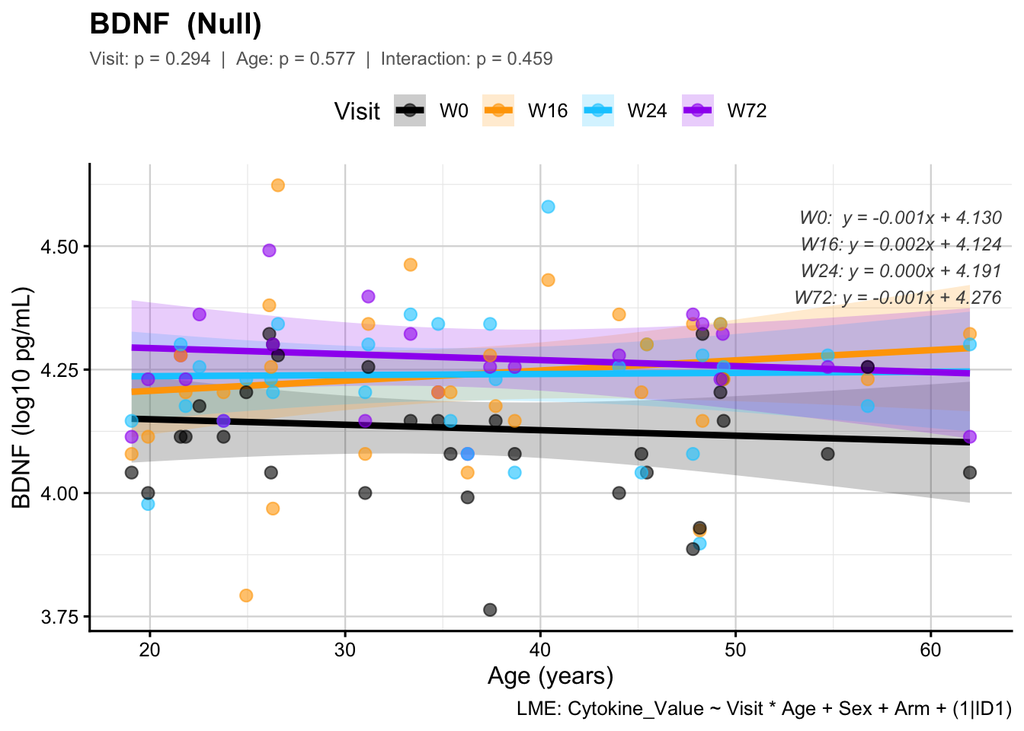

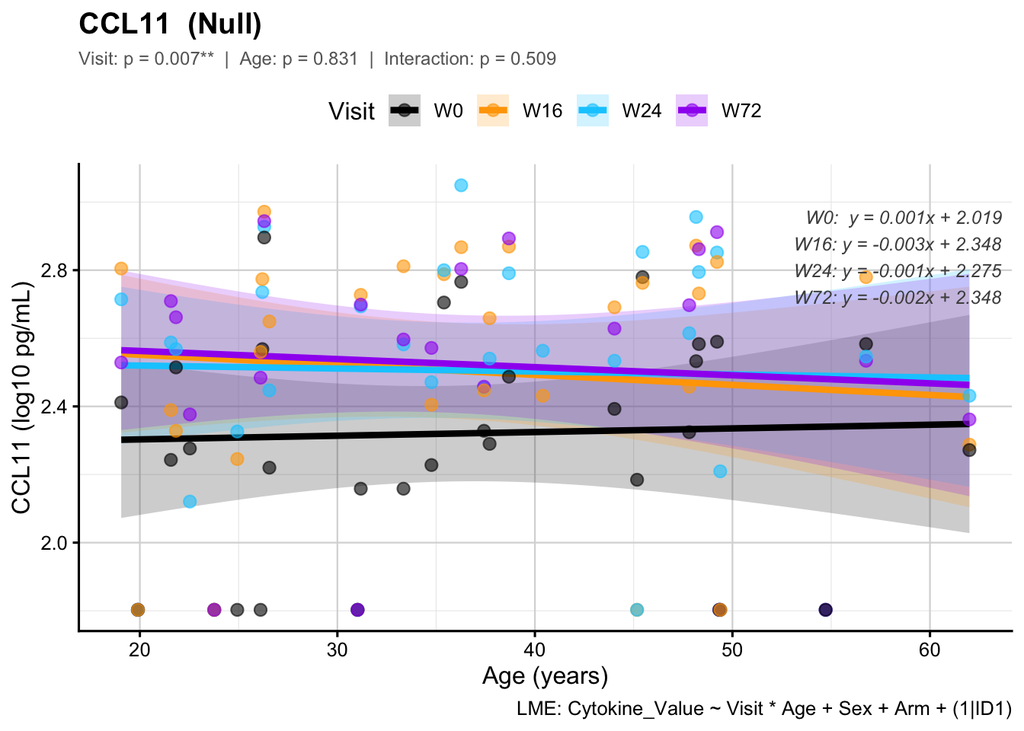

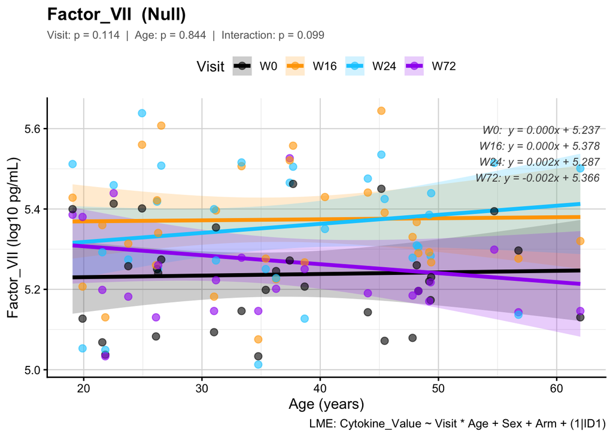

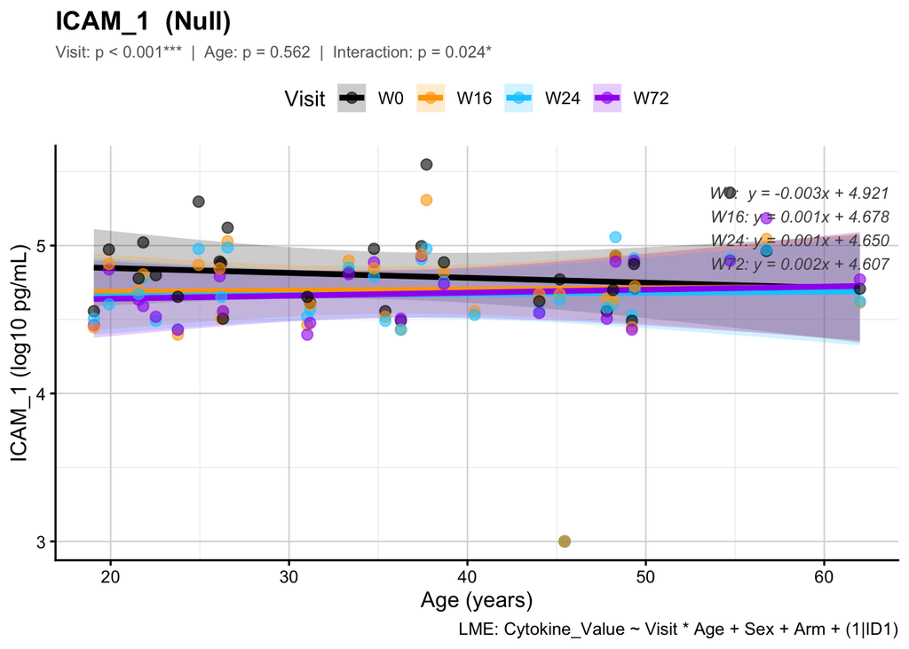

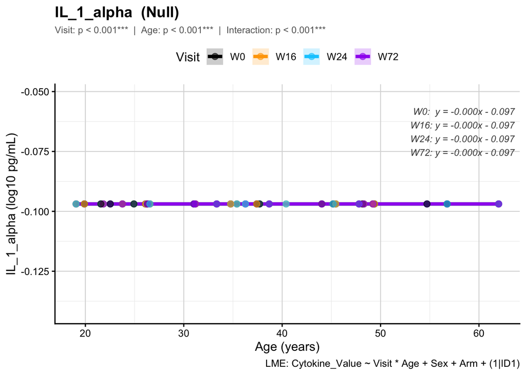

```
boundary (singular) fit: see help('isSingular')
```

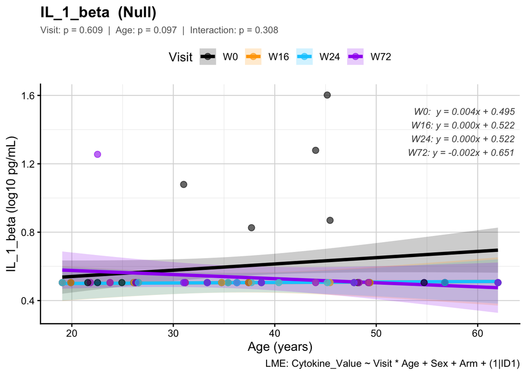

```
boundary (singular) fit: see help('isSingular')
```

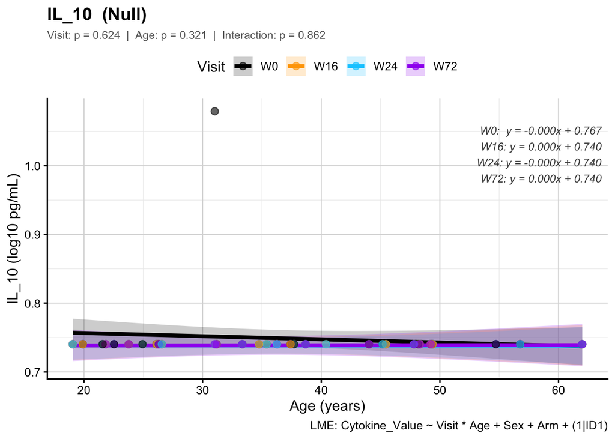

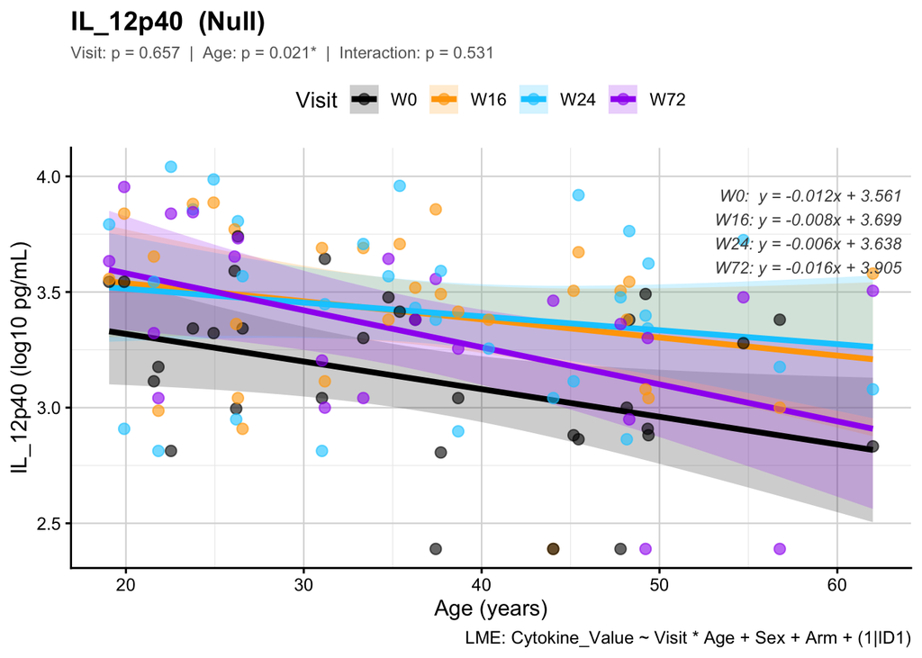

```
boundary (singular) fit: see help('isSingular')
```

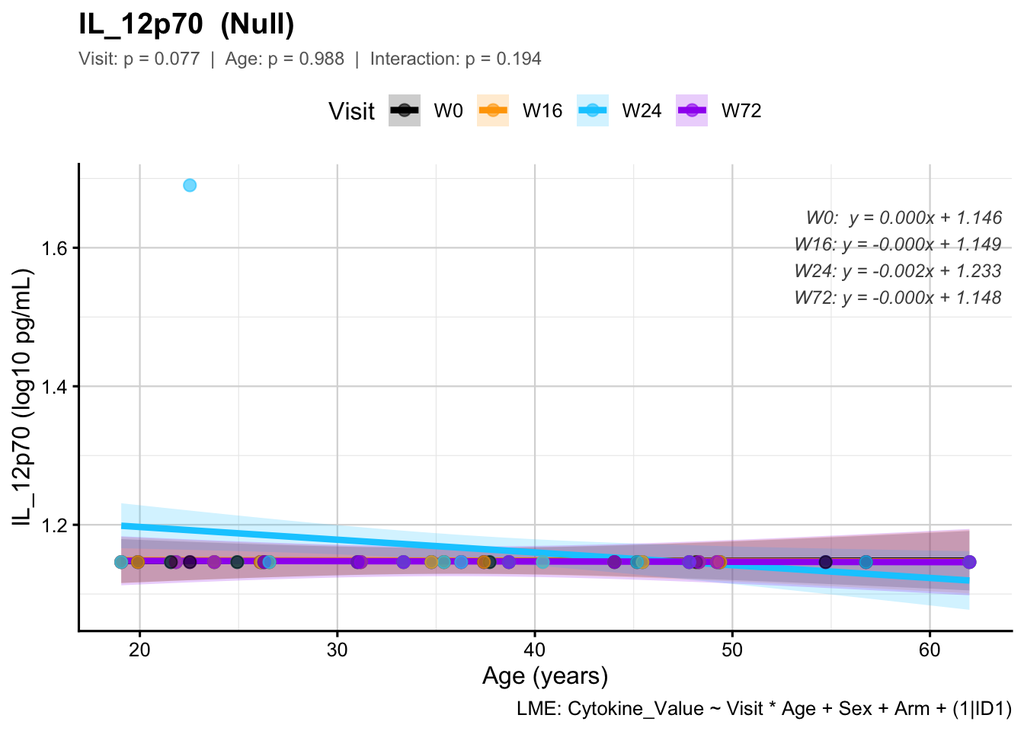

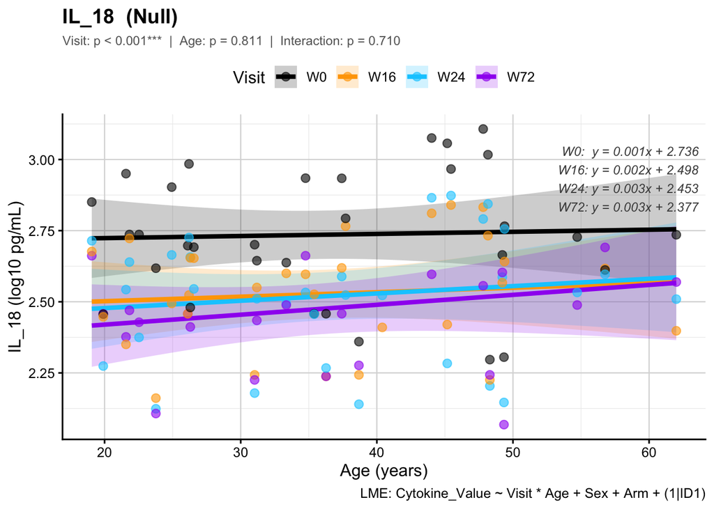

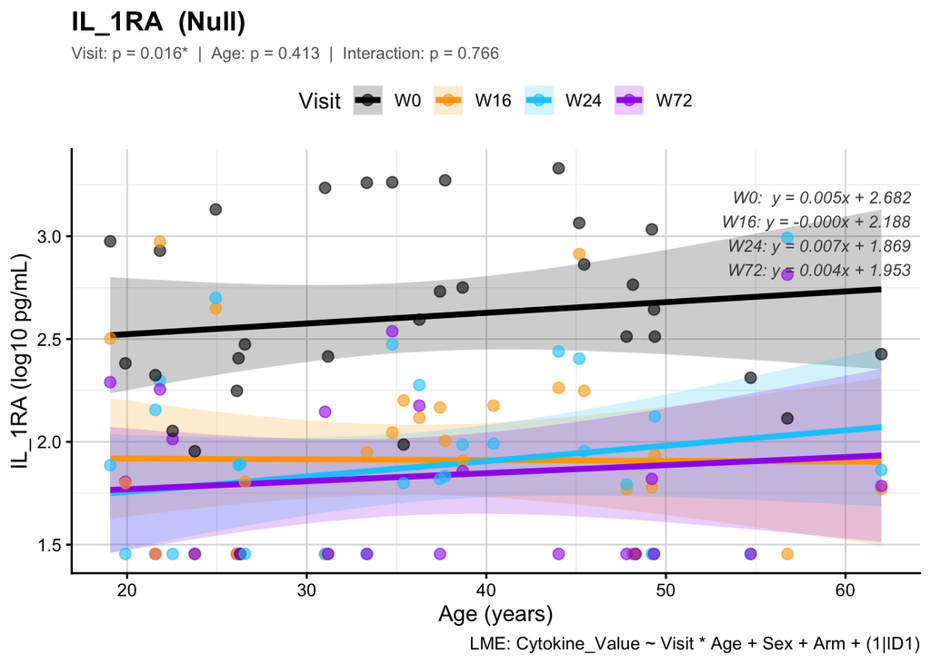

```
boundary (singular) fit: see help('isSingular')
```

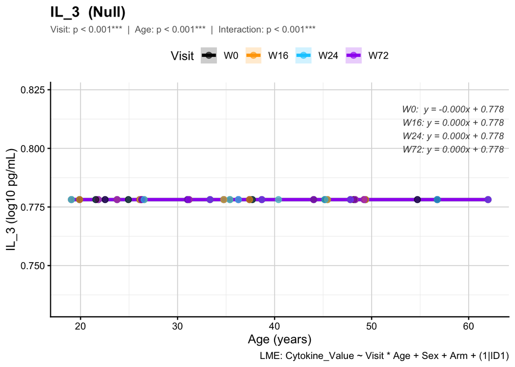

```
boundary (singular) fit: see help('isSingular')
boundary (singular) fit: see help('isSingular')
```

[88 more figures not shown]

```r
all_analyses <- list()
stimulations <- c("Null", "Mtb_Ag", "LPS", "IL1B")
covariates   <- c("Sex", "Arm")

for (stim in stimulations) {
  out_dir <- file.path(output_main, stim)
  dir.create(out_dir, recursive = TRUE, showWarnings = FALSE)

  cat(sprintf("\nStimulation: %s\n", stim))

  screening_results <- bind_rows(lapply(cytokine_cols, function(cyt) {
    screen_lme(
      data          = data_long,
      cytokine_name = cyt,
      stimulation   = stim,
      covariates    = covariates,
      min_obs       = 10,
      min_subjects  = 5
    )
  }))

  if (nrow(screening_results) == 0) {
    cat(sprintf("  No results for %s. Skipping.\n", stim))
    next
  }

  cat(sprintf("  Cytokines screened: %d\n", nrow(screening_results)))

  screening_results <- screening_results %>%
    mutate(
      Visit_p_adj       = p.adjust(Visit_p,       method = "fdr"),
      Age_p_adj         = p.adjust(Age_p,         method = "fdr"),
      Interaction_p_adj = p.adjust(Interaction_p, method = "fdr"),
      Visit_sig         = Visit_p_adj       < 0.05,
      Age_sig           = Age_p_adj         < 0.05,
      Interaction_sig   = Interaction_p_adj < 0.05,
      Any_sig           = Visit_sig | Age_sig | Interaction_sig
    ) %>%
    arrange(Interaction_p_adj)

  cat(sprintf(
    "  FDR-significant: Visit = %d | Age = %d | Interaction = %d\n",
    sum(screening_results$Visit_sig,       na.rm = TRUE),
    sum(screening_results$Age_sig,         na.rm = TRUE),
    sum(screening_results$Interaction_sig, na.rm = TRUE)
  ))

  write_xlsx(screening_results, file.path(out_dir, "LME_screening_results.xlsx"))

  for (cyt in cytokine_cols) {
    plot_lme(
      data          = data_long,
      cytokine_name = cyt,
      stimulation   = stim,
      visit_colors  = visit_colors,
      covariates    = covariates,
      save_path     = out_dir
    )
  }

  summary_table <- screening_results %>%
    select(
      Cytokine, Stimulation, N_obs, N_subjects,
      Visit_p, Visit_p_adj, Visit_sig,
      Age_p, Age_p_adj, Age_sig,
      Interaction_p, Interaction_p_adj, Interaction_sig, Any_sig
    )

  write_xlsx(summary_table, file.path(out_dir, "LME_summary_table.xlsx"))

  all_analyses[[stim]] <- list(
    screening_results = screening_results,
    cytokines_plotted = cytokine_cols
  )
}
```